# Multiple Imputation in R (answers)

Maria Sanchez and Marta Pineda-Moncusi

2023-11-22

```r
rm(list=ls())

##Install these packages if you need them:

#install.packages("knitr")
#install.packages("dplyr")
#install.packages("tibble")
#install.packages("ggcorrplot")
#install.packages("misty")
#install.packages("mice")
#install.packages("ggmice")
#install.packages("VIM")
```

# Tutorial for Multiple Imputation in R

## Introduction

Missing data (or missing values) is defined as the data value that is not stored for a variable in the observation of interest. The problem of missing data is relatively common in almost all research and can have a significant effect on the conclusions that can be drawn from the data.

A common misconception of missing data methods is the assumption that imputed values should represent “real” values. The purpose when addressing missing data is to correctly reproduce the variance/covariance matrix we would have observed if our data had not any missing information.

The aim of this practical is to discuss commonly used techniques for handling missing data and common issues that could arise when these techniques are used. We will focus on one of the most popular methods, **multiple imputation**. But, depending on the type of data and model you will be using, other techniques such as direct maximum likelihood may better serve your needs.

We will use the data set *hip.csv*. This data set is made up for this practical. The R code for this practical was developed using R 4.2.1 version.

## Load and evaluate the data set

**The Hip Replacement (HIP) data set**

The hip data set contains information on seven hundred and eight patients receiving primary hip replacement surgery for osteoarthritis (variable `id` is the unique patient identifier). Prior to the operation, patients completed a pre-operative Oxford Hip Score (OHS) and EQ5D (Euroqol) questionnaire with a follow-up questionnaire being filled in at 6-months post-surgery. The OHS consists of 12 questions asking patients to describe their hip pain and function during the past 4 weeks. An overall score is created by summing the responses to each of the 12 questions, ranging from 0 to 48, where 0 is the worst possible score (severe symptoms) and 48 the best score (excellent joint function). Variable `ohs0` is the pre-operative score and `ohs6` post-operative. The absolute change in OHS between pre- and post-operative assessments (variable `ohsdiff`) is negative if patient symptoms have improved and positive for worsening.

The pre-operative `eq5d0` contains information from 5 questions asking about a patient’s health state today, covering mobility, self-care, usual activities, pain, and anxiety. The `eq5d0` has been converted to a single summary score (variable `eq5d0`), anchored at 0 for death and 1 for full health, with some health states being worse than dead (-0.594).

Six months after their operation patients were asked about their overall satisfaction with the outcome of surgery measured on a visual analogue scale from 0 to 100 (variable `satisfaction`).

Pre-operative information was collected on `age` at the time of surgery, `sex` (0 = Male; 1 = Female), `height` (metres) and `weight` (kg) (from which body mass index (`bmi`) is calculated), `side` of surgery (Left; Right), `ethnic` group (0 = White; 1 = Non white), whether or not they are `retired` (0 = Not retired; 1 = Retired), `smoking` (0 = Non-smoker; 1 = Smoker) and `occupation` is defined as 1 if the individual is a manual worked and 0 if not. The Index of Multiple Deprivation is a measure of social deprivation, linked to the area a patient lives in (variable `imdscore`)

```r
library(dplyr)
library(tibble)

#See your working directory
getwd()

#Update your working directory to the folder where "hip.data" is stored (if necessary)
update_wd = "NO" #"NO" for keeping the current working directory. "YES" to update, plus including the new path in folder_path variable below.
if(update_wd == "YES"){
folder_path <- ("C:/")  #Remind to use / (NOT \)
setwd(folder_path)
}
```

```r
#load data
data <- tibble(read.csv("hip.csv", sep=','))


#Display the names of variables in the data set.
names(data)
```

```
##  [1] "id"           "sex"          "age"          "retired"      "ohs0"
##  [6] "ohs6"         "ohsdiff"      "eq5d0"        "height"       "weight"
## [11] "satisfaction" "ethnic"       "imdscore"     "side"         "bmi"
## [16] "smoking"      "occupation"
```

```r
#transform/include labels to data
data = data %>%
            mutate(sex = factor(sex, levels = c(0,1), labels = c("Male","Female")),
                 retired = factor(retired, levels = c(0,1), labels = c("Not retired","Retired")),
                 ethnic = factor(ethnic, levels = c(0,1), labels = c("White","Non white")),
                 side = factor(side, levels = c(0,1), labels = c("Right","Left")),
                 smoking = factor(smoking, levels = c(0,1), labels = c("Non-smoker","Smoker")),
                 occupation = factor(data$occupation, levels = c(0,1), labels = c("Non-manual worker","Manual worker")) )

#Observe/explore the data
dim(data)
```

```
## [1] 708  17
```

```r
summary(data)
```

```
##        id            sex           age               retired         ohs0
##  Min.   :  1.0   Male  :272   Min.   :31.00   Not retired:281   Min.   : 0.00
##  1st Qu.:177.8   Female:436   1st Qu.:66.00   Retired    :427   1st Qu.:13.00
##  Median :354.5                Median :75.00                     Median :20.00
##  Mean   :354.5                Mean   :73.52                     Mean   :20.03
##  3rd Qu.:531.2                3rd Qu.:82.00                     3rd Qu.:26.00
##  Max.   :708.0                Max.   :99.00                     Max.   :46.00
##
##       ohs6          ohsdiff          eq5d0             height
##  Min.   : 6.00   Min.   :-43.0   Min.   :-0.5940   Min.   :1.080
##  1st Qu.:33.00   1st Qu.:-26.0   1st Qu.: 0.0550   1st Qu.:1.610
##  Median :42.00   Median :-19.0   Median : 0.5160   Median :1.660
##  Mean   :38.63   Mean   :-18.6   Mean   : 0.3804   Mean   :1.668
##  3rd Qu.:46.00   3rd Qu.:-12.0   3rd Qu.: 0.6910   3rd Qu.:1.740
##  Max.   :48.00   Max.   : 19.0   Max.   : 1.0000   Max.   :1.970
##                                  NA's   :18        NA's   :359
##      weight       satisfaction          ethnic       imdscore        side
##  Min.   : 44.0   Min.   :  0.00   White    :300   Min.   : 0.92   Right:384
##  1st Qu.: 65.0   1st Qu.: 90.00   Non white: 53   1st Qu.: 7.07   Left :324
##  Median : 74.0   Median :100.00   NA's     :355   Median :11.07
##  Mean   : 76.1   Mean   : 89.22                   Mean   :13.82
##  3rd Qu.: 86.0   3rd Qu.:100.00                   3rd Qu.:18.86
##  Max.   :186.0   Max.   :100.00                   Max.   :48.05
##  NA's   :359     NA's   :52                       NA's   :11
##       bmi              smoking                occupation
##  Min.   :14.58   Non-smoker:411   Non-manual worker:374
##  1st Qu.:23.81   Smoker    : 84   Manual worker    :334
##  Median :26.57   NA's      :213
##  Mean   :27.31
##  3rd Qu.:30.44
##  Max.   :63.44
##  NA's   :359
```

**Quiz**

*Check the structure of the data*:

- How many cases (individuals) are in the data? 708
- How many variables do we have? 17
- Which are numeric? age, oh0, oh6, ohsdiff, EQ5D0, height, weight, satisfaction, bmi and imdscore
- Which are factor? sex, retired, ethnic, side, smoking and occupation
- Is there any variable with missing values? Yes. EQ5D0, height, weight, bmi, satisfaction, ethnic, imdscore and smoking
- Describe the outcome: Mean (-18.6), Median (Range): -19 (-43-19). Mean and median values are very close, so we can think that the distribution of the outcome is normal. You would like to check this assumption with a density plot or histogram. The majority of patients improved in terms of pain and function after surgery (negative values).

## Exploring missing data mechanisms

There are three typical mechanisms causing missing data:

- Missing completely at random (MCAR): The probability of data being missing is the same for all cases (not dependent on the observed or unobserved data)
  - In the presence of MCAR, complete cases analysis will not results in biased parameter estimates (e.g. regression coefficients)
- Missing at random (MAR): The probability of data being missing is the same only within groups defined by the observed data.
  - In the presence of MAR, **multiple imputation** methods may lead to unbiased results
- Missing not at random (MNAR): The probability of data being missing varies for reasons that are unknown to us or does depend on the unobserved data, conditional on the observed data

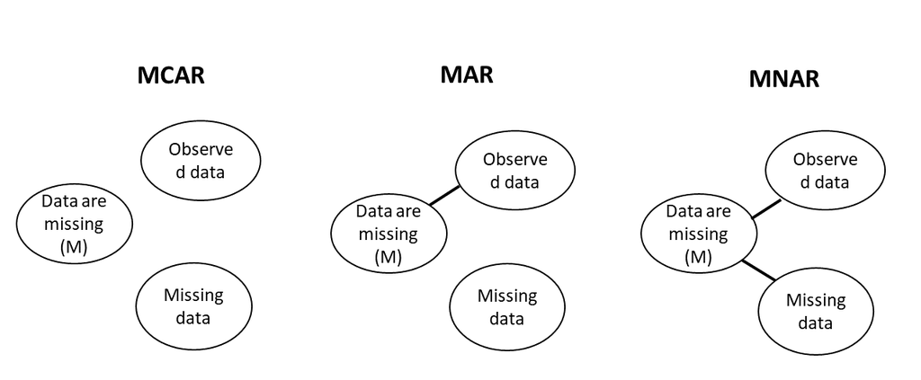

To explore the mechanism of the missing data in our data set, we can check if missingness are associated with completed variables.

1. We can check if missing values are associated to observed variables using a correlation matrix:

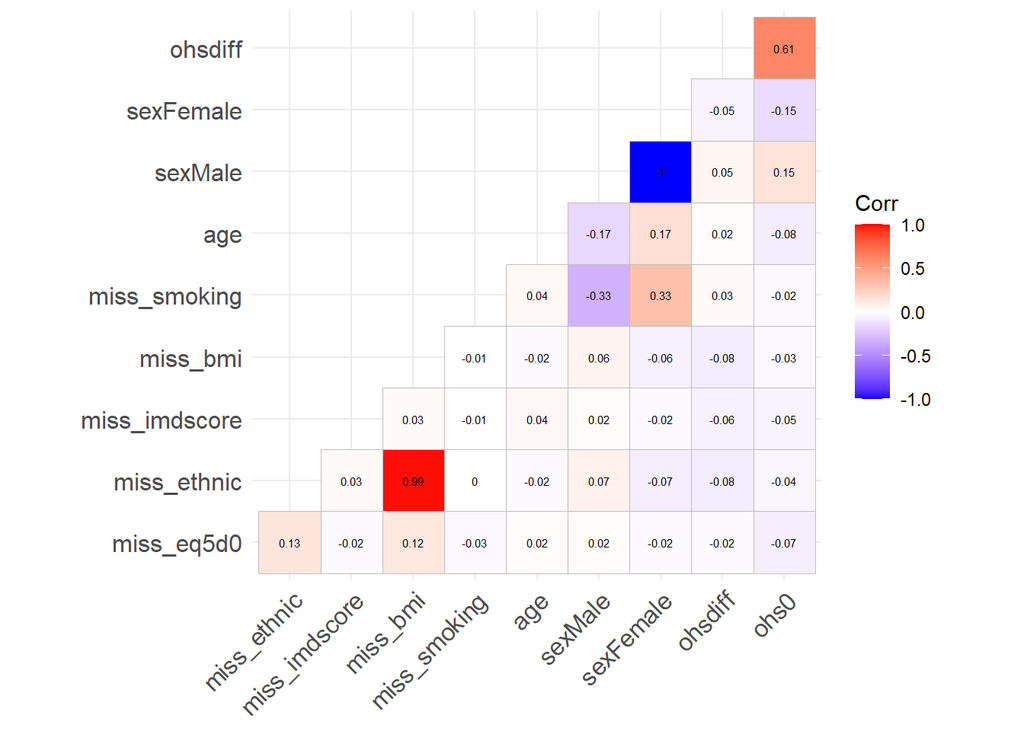

```r
#list the variables you want to test
miss_var_list = c("eq5d0", "ethnic", "imdscore", "bmi", "smoking")
complete_var  = c("age", "sex", "ohsdiff","ohs0")

library(ggcorrplot)

#Generate a data frame where missing variables are codified by 0=non-missing value and 1=missing value:
miss_data =  data %>% mutate(
  miss_eq5d0= ifelse(is.na(eq5d0),1,0),
  miss_ethnic= ifelse(is.na(ethnic),1,0),
  miss_imdscore= ifelse(is.na(imdscore),1,0),
  miss_bmi=ifelse(is.na(bmi),1,0),
  miss_smoking= ifelse(is.na(smoking),1,0) )

corr_var = c("miss_eq5d0", "miss_ethnic", "miss_imdscore", "miss_bmi", "miss_smoking", complete_var)

model.matrix(~0+., data=miss_data[corr_var]) %>%
  cor(use="pairwise.complete.obs")  %>%
  ggcorrplot(show.diag = F, type="lower", lab=TRUE, lab_size=2)
```

```r
#list the variables you want to test
miss_var_list = c("eq5d0", "bmi", "ethnic", "imdscore","smoking")
complete_var  = c("age", "sex", "retired", "ohsdiff","side","occupation")

for (v in 1:length(miss_var_list)){
 miss_var = ifelse(is.na(data[[miss_var_list[v]]]), 1, 0)
 test = glm(miss_var ~ ., data=data[complete_var] )
 print(paste("Tested variable: ", miss_var_list[v], sep=""))
 print(summary(test))   #Check p_value
}
```

```
## [1] "Tested variable: eq5d0"
##
## Call:
## glm(formula = miss_var ~ ., data = data[complete_var])
##
## Deviance Residuals:
##      Min        1Q    Median        3Q       Max
## -0.05273  -0.03337  -0.02526  -0.01727   0.98807
##
## Coefficients:
##                           Estimate Std. Error t value Pr(>|t|)
## (Intercept)             -0.0420259  0.0522513  -0.804    0.421
## age                      0.0006046  0.0007118   0.849    0.396
## sexFemale               -0.0083128  0.0124251  -0.669    0.504
## retiredRetired          -0.0088049  0.0165316  -0.533    0.594
## ohsdiff                 -0.0013361  0.0009182  -1.455    0.146
## sideLeft                -0.0076764  0.0119589  -0.642    0.521
## occupationManual worker  0.0256096  0.0198422   1.291    0.197
##
## (Dispersion parameter for gaussian family taken to be 0.02490146)
##
##     Null deviance: 17.542  on 707  degrees of freedom
## Residual deviance: 17.456  on 701  degrees of freedom
## AIC: -596.34
##
## Number of Fisher Scoring iterations: 2
##
## [1] "Tested variable: bmi"
##
## Call:
## glm(formula = miss_var ~ ., data = data[complete_var])
##
## Deviance Residuals:
##     Min       1Q   Median       3Q      Max
## -0.6271  -0.5007   0.3750   0.4845   0.6305
##
## Coefficients:
##                           Estimate Std. Error t value Pr(>|t|)
## (Intercept)              5.207e-01  1.654e-01   3.149  0.00171 **
## age                      4.356e-05  2.253e-03   0.019  0.98458
```

[output cut: 87 more lines]

```
## sexFemale                0.318854   0.034133   9.342   <2e-16 ***
## retiredRetired           0.014647   0.045414   0.323    0.747
## ohsdiff                  0.001130   0.002522   0.448    0.654
## sideLeft                 0.013892   0.032852   0.423    0.673
## occupationManual worker  0.028453   0.054508   0.522    0.602
## ---
## Signif. codes:  0 '***' 0.001 '**' 0.01 '*' 0.05 '.' 0.1 ' ' 1
##
## (Dispersion parameter for gaussian family taken to be 0.1879176)
##
##     Null deviance: 148.92  on 707  degrees of freedom
## Residual deviance: 131.73  on 701  degrees of freedom
## AIC: 834.58
##
## Number of Fisher Scoring iterations: 2
```

3. Alternative, we can use the function na.test() from the package misty: This function tests all your data set.

```r
library(misty)

#We are excluding 'id' from the dataset.
na.test(within(data, rm(id)))
```

```
##  Little's MCAR Test
##
##     n nIncomp nPattern   chi2  df  pval
##   708     480       19 277.33 219 0.005
```

*Interpretation of the function na.test()**:*

If the output is statistically significant p-value (p≤0.05), indicates that the result provides evidence against “Missing Completely at Random” (MCAR) and therefore, the missing data are MAR or MNAR. In this situation, complete cases analysis will give bias results, therefore, you need to impute.

If the result is not statistically significant p>0.05, indicates that the test is failing to reject the null hypothesis. But, it doesn’t prove that the data is MCAR, so data might or not be MCAR. If you suspect that an unobserved variable/s may explain the missingness of your data, you still need to impute your data, assuming that it is MAR.

## Multiple Imputation in R

Multiple imputation is a simulation-based statistical technique for handling missing data. It is now accepted as the best general method to deal with incomplete data. Multiple imputation was developed by Donal B. Rubin in the 1970’s.

### 1. Procedure

Multiple imputation creates more than one complete data sets (m). Each of these data sets is analysed by standard analysis software. The m results are pooled into a final point estimate plus standard error by pooling rules (“Ruben’s rules”).

Multiple imputation consists of three steps: imputation, analysis and pooling.

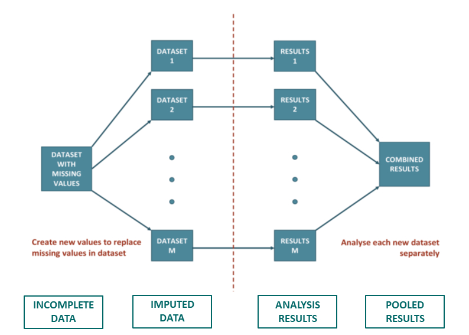

- *Imputed data:* it creates several complete data (m) sets where missing values are replaced by plausible data values. Plausible values are taken from the distribution modeled for each missing entry.
- *Analysis results:* it estimates the parameters of interest from each imputed data set.
- *Pooled results:* it pools the m parameter estimates into one estimate, and to estimate the variance. The variance combines the “within-imputation variance” and the “between-imputation variance”.

### 2. Preparing to conduct Multiple Imputation

> **NOTE:** The standard implementation of multiple imputation is based on the assumption of data being at least MAR.

When developing your imputation model, it is important to assess if your imputation model is consistent with your analytic model. Consistency means that your imputation model includes (at the very least) the same variables that are in your analytic or estimation model. This also includes any transformations to variables (e.g. log transformations, interactions) that will be needed to assess your hypothesis of interest.

For example, if the analytic model has significant interactions, then the imputation model should include them as well, if the analytic model uses a transformed version of a variable then the imputation model should use the same transformation.

Our analytic model contains:

- The outcome/dependent variable (*Y*) is `ohsdiff` = change in ohs before and after surgery
- The independent variables (*X’s*) are = `age`, `sex`, `ethnic`, `imdscore` , `bmi`, `smoking` , `eq5d0` and `ohs0`

We are going to follow the next steps to built the imputation model:

#### 2.1. Examine the number of missing values among your variables of interest

We use the command `summary` command to count the number of missing observations of missing for each variable of interest

```r
#Selecting variables of interest
analytic_model <- c("ohsdiff","age", "sex", "ethnic", "eq5d0", "imdscore", "bmi", "smoking", "ohs0")

#Observe/explore number of missing data
summary(data[analytic_model])
```

```
##     ohsdiff           age            sex            ethnic        eq5d0
##  Min.   :-43.0   Min.   :31.00   Male  :272   White    :300   Min.   :-0.5940
##  1st Qu.:-26.0   1st Qu.:66.00   Female:436   Non white: 53   1st Qu.: 0.0550
##  Median :-19.0   Median :75.00                NA's     :355   Median : 0.5160
##  Mean   :-18.6   Mean   :73.52                                Mean   : 0.3804
##  3rd Qu.:-12.0   3rd Qu.:82.00                                3rd Qu.: 0.6910
##  Max.   : 19.0   Max.   :99.00                                Max.   : 1.0000
##                                                               NA's   :18
##     imdscore          bmi              smoking         ohs0
##  Min.   : 0.92   Min.   :14.58   Non-smoker:411   Min.   : 0.00
##  1st Qu.: 7.07   1st Qu.:23.81   Smoker    : 84   1st Qu.:13.00
##  Median :11.07   Median :26.57   NA's      :213   Median :20.00
##  Mean   :13.82   Mean   :27.31                    Mean   :20.03
##  3rd Qu.:18.86   3rd Qu.:30.44                    3rd Qu.:26.00
##  Max.   :48.05   Max.   :63.44                    Max.   :46.00
##  NA's   :11      NA's   :359
```

**Quiz**

**NOTE**: At this point, you can decide if you want to remove variables with a high number of missingness from the analytic model, and therefore, for the imputation model, as they might mess up the imputation.

#### 2.2. Missing value patterns

Types of missing data patterns:

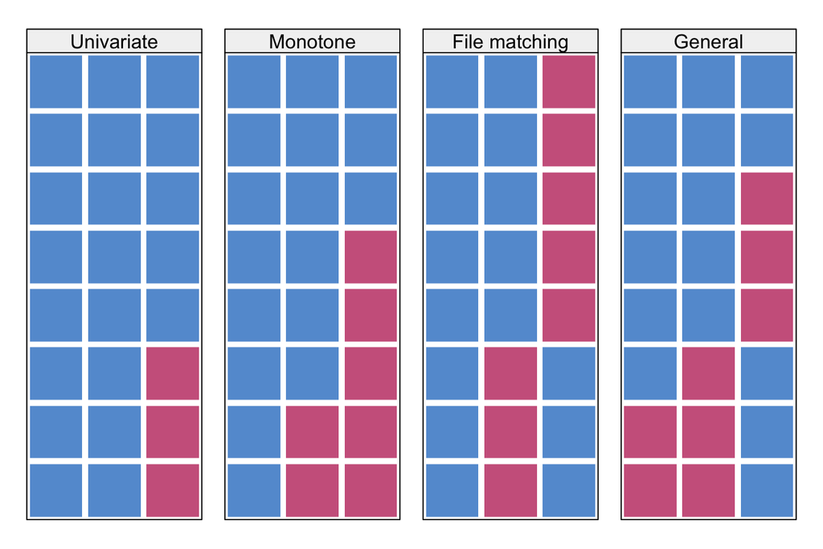

*Source: Flexible Imputation of Missing Data, Second Edition. Author: Stefvan Buuren*

Some missing data patterns in multivariate data. Blue is observed, red is missing:

1. *Univariate and multivariate*. A missing data pattern is said to be *univariate* if there is only one variable with missing data.
2. *Monotone and non-monotone (or general)*. A missing data pattern is said to be *monotone* when, if the variables are ordered from least to most missing, then all observations of a variable contain missing in the observations in which the prior variable contains missing (*it can occur as a result of drop-out in longitudinal studies*). If the pattern is not monotone, it is called *non-monotone or general*
3. *Unconnected and connected (file matching)*. A missing data pattern is said to be *connected* if any observed data point can be reached from any other observed data point through a sequence of horizontal or vertical moves (like the rook in chess).

The missing data pattern influences the amount of information that can be transferred between variables.

Imputation can be more precise if other variables are non-missing for those cases that are to be imputed. The reverse is also true. Predictors are potentially more powerful if they have are non-missing in rows that are vastly incomplete. This section discusses various measures of the missing data pattern.

R has several functions to inspect the missing data pattern.

The mice package contains a function to inspect the missing data pattern: `md.pattern()`

```r
#Selecting variables with missing data
miss_vars <- c( "eq5d0", "ethnic","imdscore", "bmi", "smoking")

#Exploring missing pattern with md.pattern() function
library(mice)
md.pattern(data[miss_vars], plot=FALSE)
```

```
##     imdscore eq5d0 smoking ethnic bmi
## 238        1     1       1      1   1   0
## 4          1     1       1      1   0   1
## 231        1     1       1      0   0   2
## 105        1     1       0      1   1   1
## 101        1     1       0      0   0   3
## 1          1     0       1      1   1   1
## 13         1     0       1      0   0   3
## 1          1     0       0      1   1   2
## 3          1     0       0      0   0   4
## 3          0     1       1      1   1   1
## 5          0     1       1      0   0   3
## 1          0     1       0      1   1   2
## 2          0     1       0      0   0   4
##           11    18     213    355 359 956
```

- Can you please interpreter the output table? what do you think it is displaying?

*Interpretation of the output table:*

In the main body of the output table the values “1” indicates non-missing value and “0” indicates missing value. The first column shows the number of unique missing data patterns.

There are 238 observations with non-missing values, and there are 4 observations with non-missing values except for the variable `bmi`. The rightmost column shows the number of missing variables in a particular missing pattern. For example, the first row has no missing value and it is “0” in the row. The last row counts the number of missing values for each variable. For example, the variable `imdscore` contains 11 missing values and the variable `bmi` contains 359 missing values. This table can be helpful when you decide to drop some observations with missing variables exceeding a preset threshold.

*Visual presentation of missing data pattern:*

We are using three different R functions to display visually the patterns of the missing data:

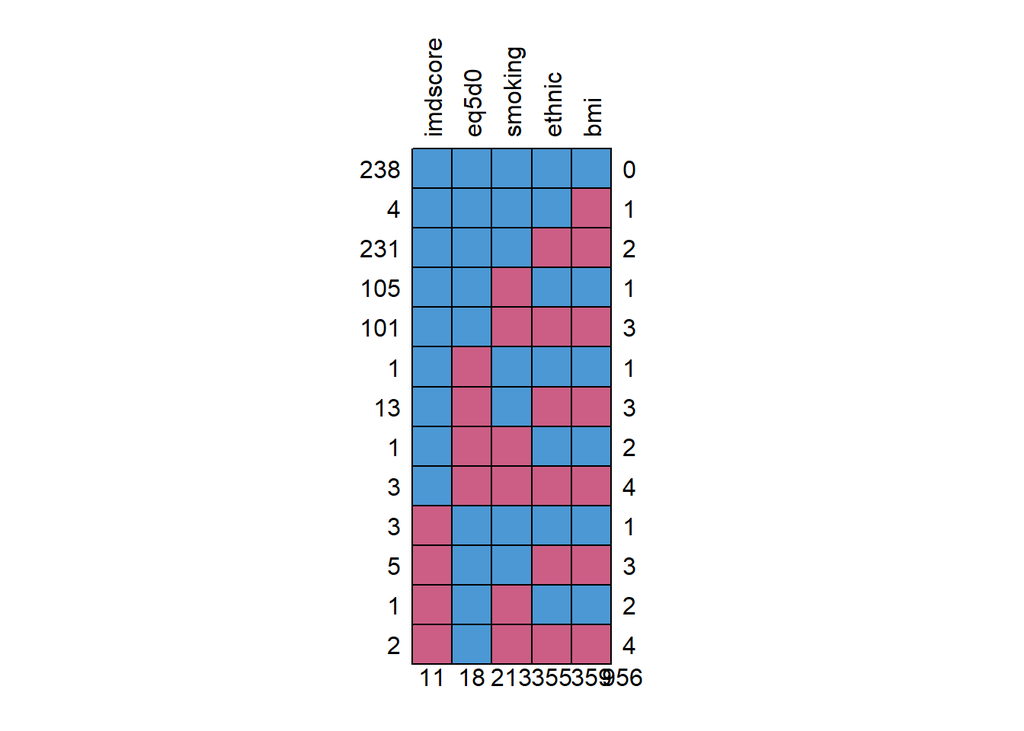

```r
library(mice)
library(ggmice)
library(VIM)

md.pattern(data[miss_vars], plot=TRUE, rotate.names=TRUE)
```

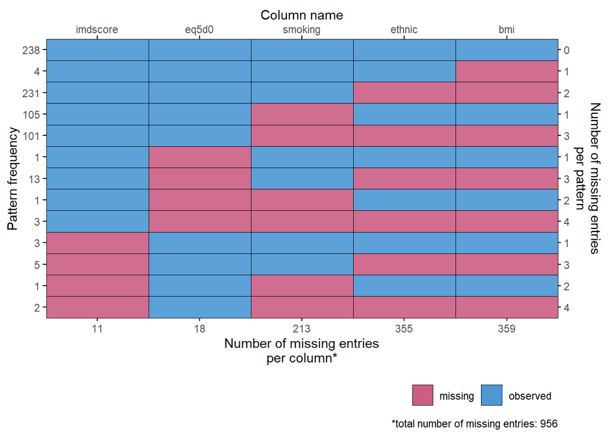

```r
plot_pattern(data[miss_vars], vrb = "all", square = FALSE, rotate = FALSE, cluster = NULL)
```

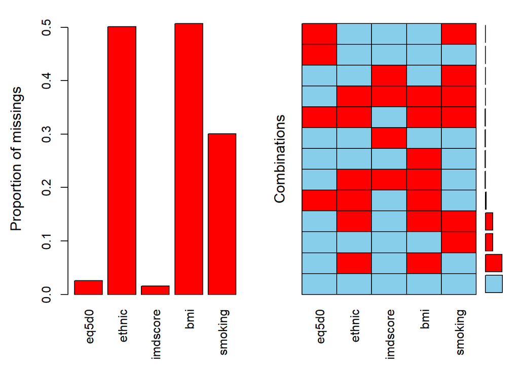

```r
aggr(data[miss_vars], numbers=FALSE, prop=TRUE)
```

*Interpretation of the plots:*

See more at: [Chapter 4 Multivariate missing data](https://stefvanbuuren.name/fimd/ch-multivariate.html)

**Quiz**

- What type of missing data pattern you think we have in our data set?

  The displayed patterns are non-monotone (i.e., general).

#### 2.3. If necessary, identify potential auxiliary variables

Auxiliary variables are variables in your data set that are either correlated with a missing variable(s) (the recommendation is r > |0.4|) or are believed to be associated with missingness. These are factors that are not of particular interest in your analytic/main model, but they are added to the imputation model to increase power and/or to help make the assumption of MAR more plausible.

Explore missingness versus potential auxiliary variables (variables non included in our main model):

Analytic/main model:

- The **outcome** or **dependent variable** (*Y*) for this study is `ohsdiff` = change in ohs before and after surgery
- The **independent variables** (*X’s*) are = `age`, `sex`, `bmi`, `ethnic`, `imdscore` , `smoking`

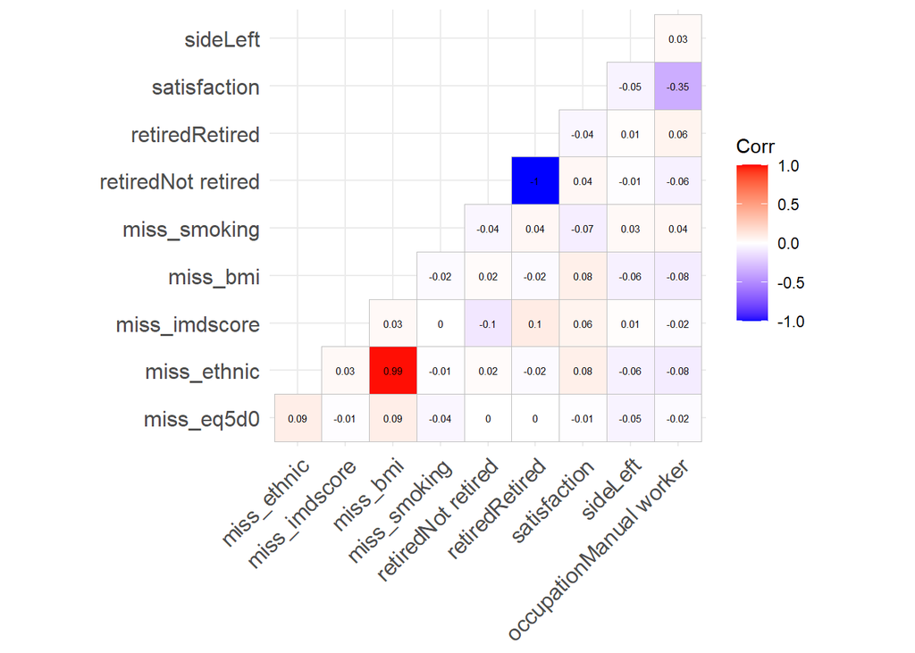

```r
library(ggcorrplot)

#explore which other variables we have available in the data set
names(data)

#list the variables you want to test
miss_var_list = c("eq5d0", "ethnic", "imdscore", "bmi", "smoking")
auxiliar_var  = c("retired", "satisfaction", "side", "occupation")

#Generate a data frame where missing variables are codified by 0=non-missing value and 1=missing value:
miss_data =  data %>% mutate(
  miss_eq5d0= ifelse(is.na(eq5d0),1,0),
  miss_ethnic= ifelse(is.na(ethnic),1,0),
  miss_imdscore= ifelse(is.na(imdscore),1,0),
  miss_bmi=ifelse(is.na(bmi),1,0),
  miss_smoking= ifelse(is.na(smoking),1,0) )

corr_var = c("miss_eq5d0", "miss_ethnic", "miss_imdscore", "miss_bmi", "miss_smoking", auxiliar_var)

model.matrix(~0+., data=miss_data[corr_var]) %>%
  cor(use="pairwise.complete.obs")  %>%
  ggcorrplot(show.diag = F, type="lower", lab=TRUE, lab_size=2)
```

You need to think about which variables should be include in the multiple imputation as auxiliaries (if any).

**Quiz**

#### 2.4. Missing variables with non-linear effects and interactions

There is often a need for transformed, combined or recoded versions of the data. In the case of incomplete data, one could impute the original, and transform the completed original afterwards, or transform the incomplete original and impute the transformed version.

##### 2.4.1. Checking non-linear effect between numeric variables and outcome.

If we know that there is evidence of a non-linear association between a numeric variable and the outcome, we should check it and transform the variable (if needed):

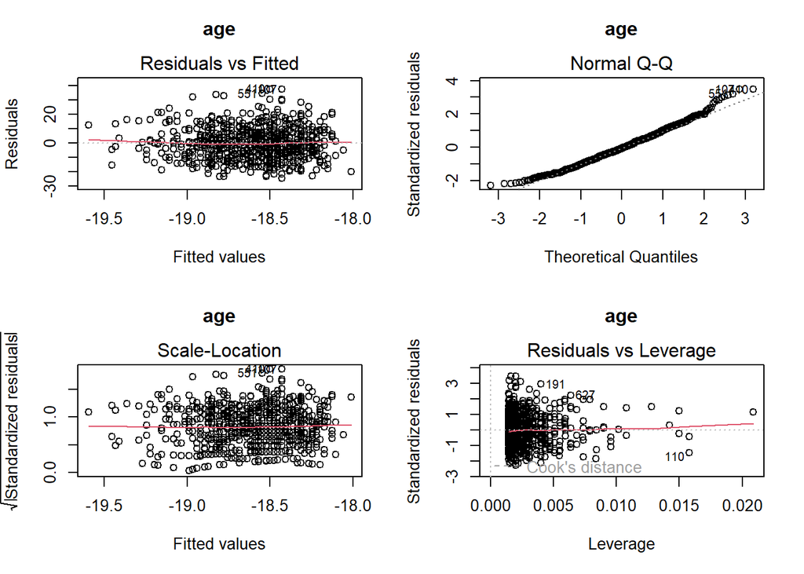

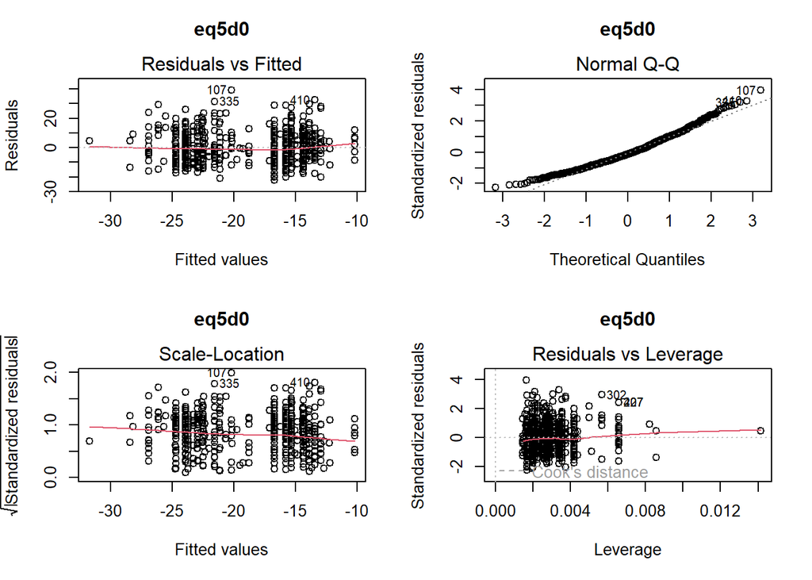

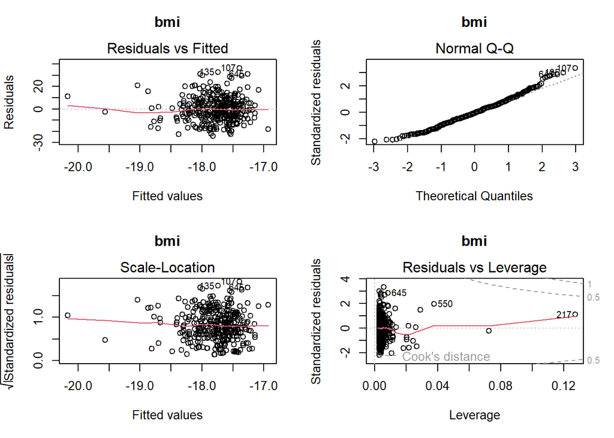

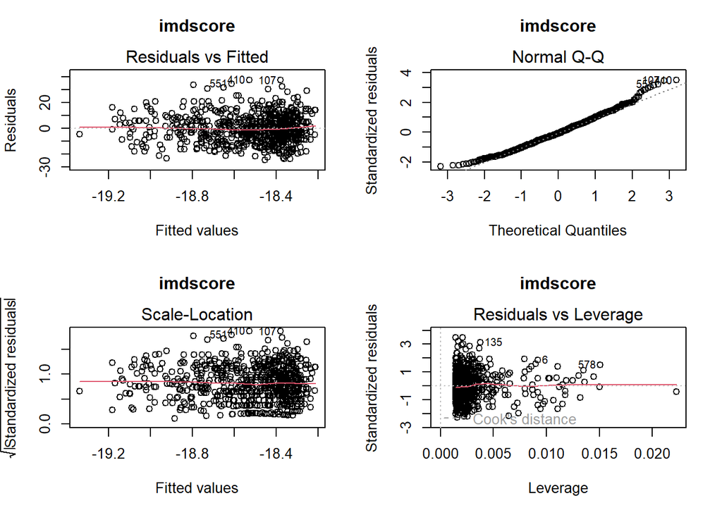

```r
#List of the variables you want to test (numeric variables)
num_var = c("age", "eq5d0", "bmi", "imdscore" )
outcome = "ohsdiff"

for (v in 1:length(num_var)){
  df = cbind(data[num_var[v]],outcome = data[[outcome]])
  linear_test = lm(outcome ~ ., data = df)
  par(mfrow = c(2, 2))
  plot(linear_test,main=paste(num_var[v],"\n",sep=""))
}
```

*Interpretation of the plots:*

The diagnostic plots show residuals in four different ways

- *Residuals vs Fitted*: Used to check the linear relationship assumptions. A horizontal line, without distinct patterns is an indication for a linear relationship, what is good.
- *Normal Q-Q*: Used to examine whether the residuals are normally distributed. It’s good if residuals points follow the straight dashed line.
- *Scale-Location (or Spread-Location)*: Used to check the homogeneity of variance of the residuals (homoscedasticity). Horizontal line with equally spread points is a good indication of homoscedasticity.
- *Residuals vs Leverage*: Used to identify influential cases, that is extreme values that might influence the regression results when included or excluded from the analysis.

**Quiz**

- Is the relationship between independent numeric variables and outcome linear? if it is not, what do your think we should do? Transform the variables. Simplest e.g. Categorization

##### 2.4.2. Checking potential interaction effects

An interaction effect occurs when the effect of one variable on outcome depends on the value of another variable. If we suspect that there is an interaction in our analytic model, it should be included in the imputation model.

Based on previous literature, `sex` can be a potential effect modifier of the relationship between `bmi` and `ohsdiff` (outcome). Thus, we should check if the interaction effect exists and then include it in the imputation model.

R has the `interaction.plot()` function built-in, however, you can only test one numeric variable vs two factors. Since `bmi` and the `outcome` are numeric, we will categorise `bmi` to run this function.

`interaction.plot()` arguments:

- x.factor = a factor variable whose levels will be on the X-axis. (aka. x-axis variable)
- trace.factor = the second-factor variable whose levels will be represented as traces (aka. variable for lines).
- response = a numeric response variable. (aka. y-axis variable)
- fun = The function to compute the summary, e.g. median.
- ylab = Y-axis label of the plot.
- xlab = X-axis label of the plot.
- trace.label = Label for the legend.
- col = A vector of colors used for all traces.
- lyt = A type of the lines drawn.
- lwd = Width of the lines drawn.

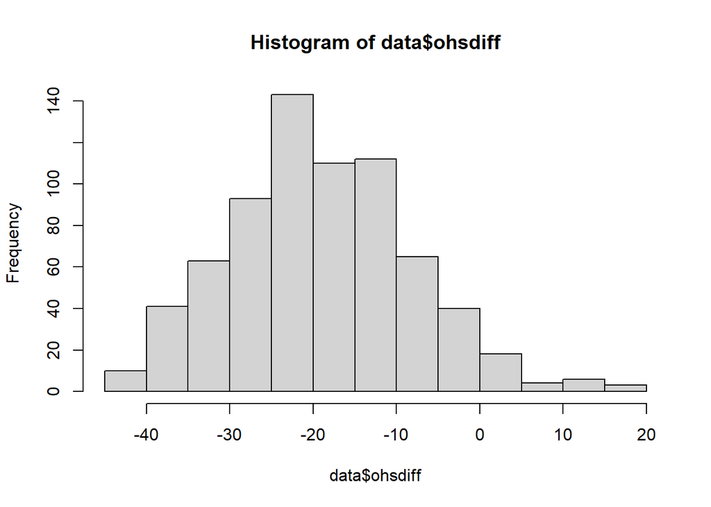

```r
##1) Check outcome distribution:
#By ploting the histogram we can see if the outcome distribution is skewed or not.
hist(data$ohsdiff)
```

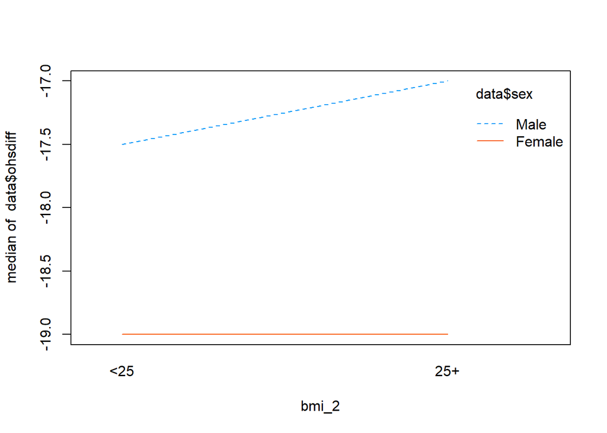

```r
#If the outcome has a normal distribution, use de mean, otherwise use the median (ie. fun = mean OR fun = median)

##2.A) Spliting bmi in 2 categories:
bmi_2 = ifelse(data$bmi >= 25, "25+", "<25")

#interaction.plot using median of ohsdiff (outcome)
interaction.plot(x.factor=bmi_2, trace.factor=data$sex, response=data$ohsdiff, fun = median,  col = c("#0198f9", "#f95801"))
```

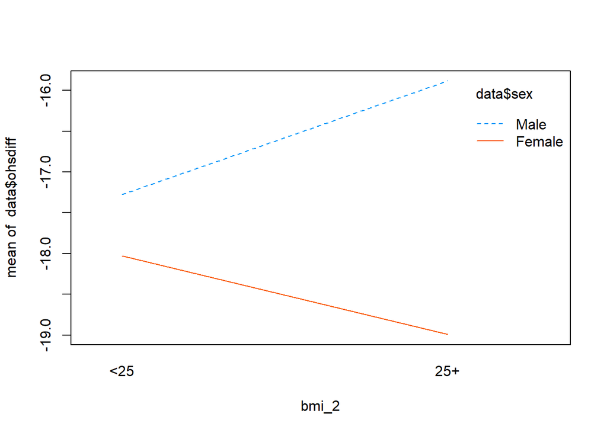

```r
#interaction.plot using mean of ohsdiff (outcome)
interaction.plot(x.factor=bmi_2, trace.factor=data$sex, response=data$ohsdiff, fun = mean,  col = c("#0198f9", "#f95801"))
```

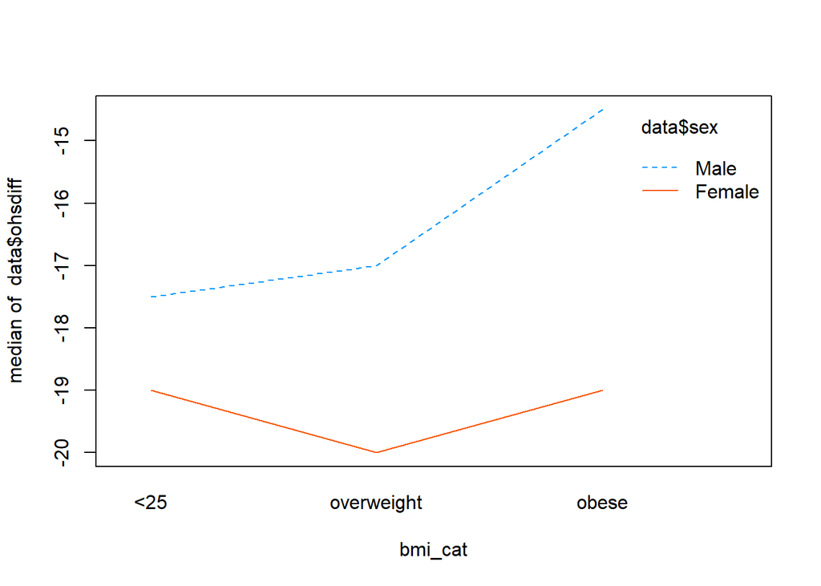

```r
##2.B) Spliting bmi in >2 categories:
bmi_cat=with(data, cut(bmi, breaks = c(0,18.5,25,30,70), labels = c('underweight','normal', 'overweight', 'obese'),right=FALSE))

bmi_cat=with(data, cut(bmi, breaks = c(0,25,30,70), labels = c('<25', 'overweight', 'obese'),right=FALSE))

#interaction.plot using median of ohsdiff (outcome):
interaction.plot(x.factor=bmi_cat, trace.factor=data$sex, response=data$ohsdiff, fun = median,  col = c("#0198f9", "#f95801"))
```

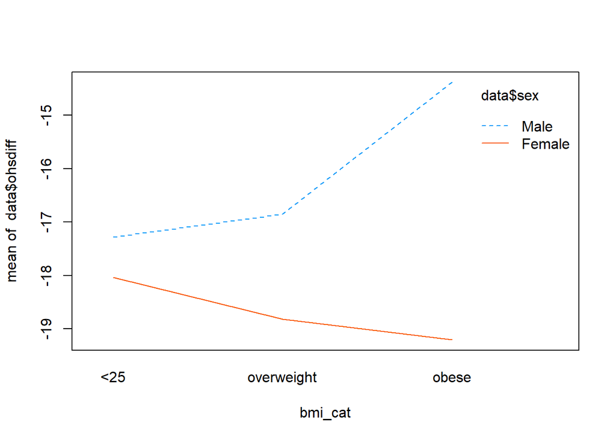

```r
#interaction.plot using mean of ohsdiff (outcome):
interaction.plot(x.factor=bmi_cat, trace.factor=data$sex, response=data$ohsdiff, fun = mean,  col = c("#0198f9", "#f95801"))
```

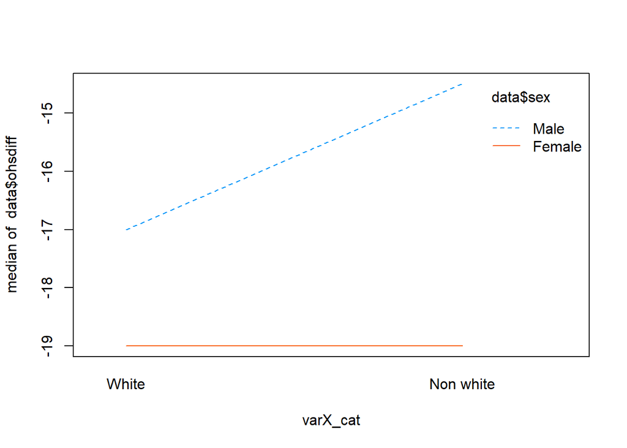

```r
## Try test interaction with other independent variable.

##Categorise varX if needed:
varX_cat = data$ethnic

#interaction.plot using median of ohsdiff (outcome):
interaction.plot(x.factor=varX_cat, trace.factor=data$sex, response=data$ohsdiff, fun = median,  col = c("#0198f9", "#f95801"))
```

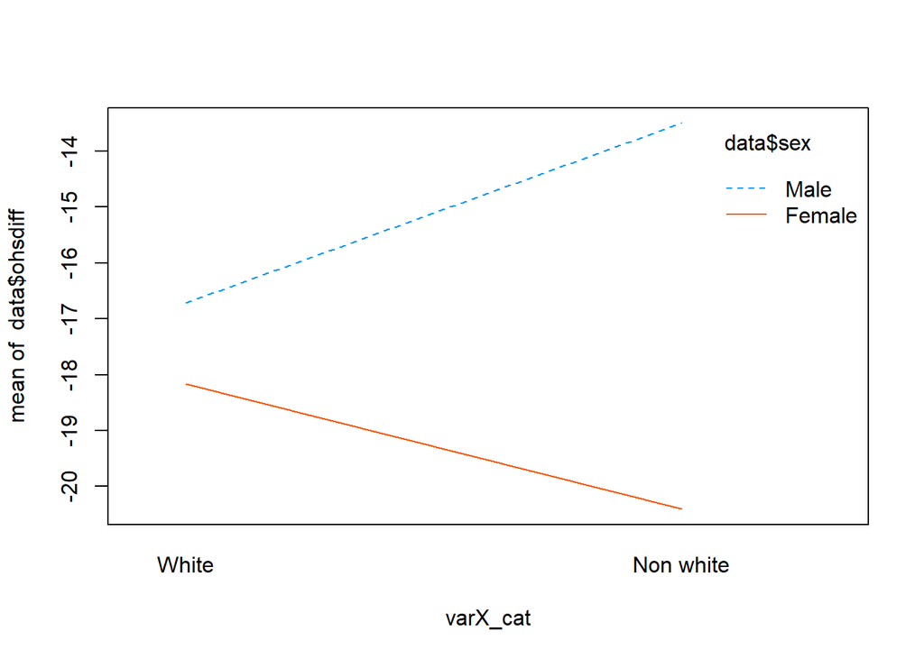

```r
#interaction.plot using mean of ohsdiff (outcome):
interaction.plot(x.factor=varX_cat, trace.factor=data$sex, response=data$ohsdiff, fun = mean,  col = c("#0198f9", "#f95801"))
```

*Interpretation the plots**:*

In general, if the two lines on the interaction plot are parallel then there is no interaction effect. However, if the lines intersect then there is likely an interaction effect.

**Quiz**

Do you think that `sex` is an effect modifier of the relationship between `bmi` and `ohsdiff`? No, it is not probably that sex is an effect modifier.

##### 2.4.3. **How do I treat variable transformations such as logs, quadratics and interactions?**

Most of the current literature on multiple imputation supports the method of treating variable transformations as “just another variable” (mainly if the analysis model is linear regression).

But, if you want to maintain the property of your data in the resulting imputed values, **mice** package in R (*further details in* [RDocumentation](https://www.rdocumentation.org/packages/mice/versions/3.14.0/topics/mice) *or typing* help(mice) *in your console*) has a built-in approach, called *passive imputation*, to deal with situations as described above. The goal of passive imputation is to maintain the consistency among different transformations of the same data.

### 3. Imputations with mice (Multivariate Imputation by Chained Equations)

The **mice** package (*further details in* [RDocumentation](https://www.rdocumentation.org/packages/mice/versions/3.14.0/topics/mice) *or typing* help(mice) *in your console*) implements a method to complete missing data based on Fully Conditional Specification, where each incomplete variable is imputed by a separate model. Then name of this function is the same than the package (i.e., `mice()` )

A simple version of the code for running the mice() function can looks as following:  
**mice(data, maxit=10, m = 5,seed=60109)**

where:

- data: your data frame
- maxit: is the number of iterations for each imputation. The default is 5. It is important that the imputations for all variables reach convergence, otherwise they will be inaccurate.
- m: number of multiple imputations (multiple data sets returned by the function). The observed data will be the same across the imputed data sets; only the values that had originally been missing will differ. The default number of imputations is 5.

When using the mice package, the steps for your analysis are the following:

1. First your create your m imputed data sets. (mice() - function)
2. Then you do your analysis on each of these data sets. (with() - function)
3. In the end you combine these results together. (pool() - function)

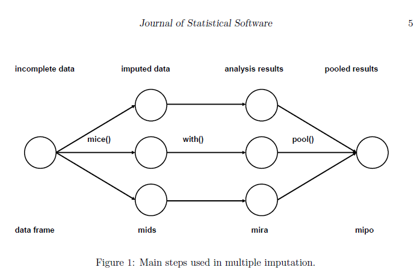

#### 3.1. Selecting the number of imputations (*m*)

Generally the more the better, but then the analysis takes longer to run and it consume more computational resources. A thumb up rule regarding the percentage of missingness is commonly used: if there is a 10% of missing, include 10 imputations; if there is a 20% missing, run 20 imputations, etc.

> NOTE: Although our data have more than 50% of missing values, we will use the default (m=5) in this example to save computation time.

#### 3.2. Choosing imputation methods.

| Method | Description | Scale type | Default |
| --- | --- | --- | --- |
| pmm | Predictive mean matching | numeric | Y |
| norm | Bayesian linear regression | numeric |  |
| norm.nob | Linear regression, non-Bayesian | numeric |  |
| mean | Unconditional mean imputation | numeric |  |
| 2L.norm | Two-level linear model | numeric |  |
| logreg | Logistic regression | factor, 2 levels | Y |
| polyreg | Multinomial logit model | factor, >2 levels | Y |
| polr | Ordered logit model | ordered, >2 levels | Y |
| lda | Linear discriminant analysis | factor |  |
| sample | Random sample from the observed data | any |  |

- Which variables we want to impute? EQ5D0, bmi, ethnic, imdscore and smoking

The `mice` package assumes a distribution for each variable and imputes missing variables according to that distribution. Hence, it is important to correctly specify each of these distributions. `mice` automatically chooses distributions for variables.

If we would like to change the methods used to impute the missing values, we can do it by changing the methods’ characteristics.

*You can follow the following three lines of the code*  
3.1 Choose the variables we want to impute  
3.2 Save the name of the variables that will be included in the imputation model  
3.3 Check the imputation method used for each variable

```r
library(mice)

##3.1) Choose the variables we want to include in the imputation model
names(data)

##3.2) Select them
impmodel_var=c("age","sex","ohs0","ohsdiff","ethnic","eq5d0","bmi","imdscore","smoking") #3.2

#We run the mice code with 0 iterations(it is just for the purpose of this example)
imp <- mice(data[impmodel_var], m=5, maxit=0, seed=60109)
#Check the method mice used to impute
imp$method

#mice has identified the correct distribution for each variable. But, if you want to change the method used, you can do the following:

meth <- imp$method

# Numeric variables - normal distribution (we are using "Linear regression, non-Bayesian" method to impute bmi)
norm <- c("bmi")
# Numeric variables - non-normal distribution
nonnorm <- c("eq5d0", "imdscore")
# Dichotomous variable
log <- c("ethnic", "smoking")

# Turn their methods matrix into the specified imputation models
meth[norm] <- "norm.nob"
meth[nonnorm] <- "pmm"
meth[log] <- "logreg"

imp2 <- mice(data[impmodel_var], m=5, maxit = 0, method = meth, seed=60109)
```

```r
#3.3) Check that mice is using the specific method
imp2$method
```

```
##        age        sex       ohs0    ohsdiff     ethnic      eq5d0        bmi
##         ""         ""         ""         ""   "logreg"      "pmm" "norm.nob"
##   imdscore    smoking
##      "pmm"   "logreg"
```

### 4. Pooling results

The pool() function combines the estimates from m repeated complete data analyses using Rubin’s rules. The typical sequence of steps to do a multiple imputation analysis is:

4.1. Impute the missing data by the mice function, resulting in a multiple imputed data set (class mids);

4.2 Fit the model of interest (scientific model) on each imputed data set by the with() function, resulting an object of class mira;  
*Classic statistical analysis has been implemented/are compatible to with() function and can be called in the argument ‘expr=’ (for expression), such as linear regression* (*lm()).*

4.3 Pool the estimates from each model into a single set of estimates and standard errors, resulting is an object of class mipo;

Optionally, compare pooled estimates from different scientific models by the pool.compare() function.

We create the impute data sets with the function `mice`:

```r
impmodel_var=c("age","sex","ohs0","ohsdiff","ethnic","eq5d0","bmi","imdscore","smoking")
imp = mice(data[impmodel_var], maxit=10, m = 5, seed=60109)  #4.1
```

```r
fit = with(data=imp,expr = lm(ohsdiff~age+sex+bmi+eq5d0+ethnic+imdscore+smoking+ohs0)) #4.2
summary(pool(fit), conf.int = TRUE) #4.3
```

```
##              term     estimate  std.error   statistic         df      p.value
## 1     (Intercept) -45.55267295 4.37454925 -10.4131124  19.815470 1.758696e-09
## 2             age   0.08143481 0.02999356   2.7150770 366.990501 6.939110e-03
## 3       sexFemale   1.17602939 0.70285340   1.6732215 381.852610 9.510267e-02
## 4             bmi   0.18934270 0.10052389   1.8835593   9.611156 9.019527e-02
## 5           eq5d0  -0.86629440 1.44773881  -0.5983775 304.731295 5.500325e-01
## 6 ethnicNon white  -0.13894990 0.97725514  -0.1421838 115.658894 8.871822e-01
## 7        imdscore  -0.03233099 0.03696526  -0.8746316 365.742018 3.823484e-01
## 8   smokingSmoker  -0.30304636 0.96771460  -0.3131567  76.758155 7.550109e-01
## 9            ohs0   0.79330939 0.05167490  15.3519282 497.855121 7.919158e-44
##          2.5 %       97.5 %
## 1 -54.68327348 -36.42207241
## 2   0.02245401   0.14041561
## 3  -0.20591809   2.55797687
## 4  -0.03587288   0.41455828
## 5  -3.71512481   1.98253602
## 6  -2.07458701   1.79668722
## 7  -0.10502211   0.04036014
## 8  -2.23010920   1.62401648
## 9   0.69178163   0.89483716
```

**AVOID***:*

- *Averaging the data*: You might be tempted to average the multiply imputed data, and analyze the averaged data as if it were complete. This method yields incorrect standard errors, confidence intervals and p-values, and thus should not be used if any form of statistical testing or uncertainty analysis is to be done on the imputed data. The reason is that the procedure ignores the between-imputation variability, and hence shares all the drawbacks of single imputation
- *Stack imputed data*: creating m×n complete records by stacking the imputed data, where each record is weighted by a factor 1/m, so that the total sample size is equal to n. While the estimated regression coefficients are unbiased, we cannot trust the standard errors, t-values and so on. An advantage of stacking over averaging is that it is easier to analyze categorical data. Although stacking can be useful in specific contexts, like variable selection, in general it is not recommended.

### 5. Checking after imputation

#### 5.0 We can observe which values has been imputed:

- The `stripplot()` is useful to study the distributions in data sets with a low number of data points.
- For large data sets it is more appropriate to use the function `bwplot()` that produces side-by-side box-and-whisker plots for the observed and synthetic data.

```r
impmodel_var=c("age","sex","ohs0","ohsdiff","ethnic","eq5d0","bmi","imdscore","smoking") #3.2

imp = mice(data[impmodel_var], maxit=10, m = 5, seed=60109)  #4.1
```

```r
fit = with(data=imp,expr = lm(ohsdiff~age+sex+bmi+eq5d0+ethnic+imdscore+smoking+ohs0)) #4.2
summary(pool(fit), conf.int = TRUE) #4.3
```

```
##              term     estimate  std.error   statistic         df      p.value
## 1     (Intercept) -45.55267295 4.37454925 -10.4131124  19.815470 1.758696e-09
## 2             age   0.08143481 0.02999356   2.7150770 366.990501 6.939110e-03
## 3       sexFemale   1.17602939 0.70285340   1.6732215 381.852610 9.510267e-02
## 4             bmi   0.18934270 0.10052389   1.8835593   9.611156 9.019527e-02
## 5           eq5d0  -0.86629440 1.44773881  -0.5983775 304.731295 5.500325e-01
## 6 ethnicNon white  -0.13894990 0.97725514  -0.1421838 115.658894 8.871822e-01
## 7        imdscore  -0.03233099 0.03696526  -0.8746316 365.742018 3.823484e-01
## 8   smokingSmoker  -0.30304636 0.96771460  -0.3131567  76.758155 7.550109e-01
## 9            ohs0   0.79330939 0.05167490  15.3519282 497.855121 7.919158e-44
##          2.5 %       97.5 %
## 1 -54.68327348 -36.42207241
## 2   0.02245401   0.14041561
## 3  -0.20591809   2.55797687
## 4  -0.03587288   0.41455828
## 5  -3.71512481   1.98253602
## 6  -2.07458701   1.79668722
## 7  -0.10502211   0.04036014
## 8  -2.23010920   1.62401648
## 9   0.69178163   0.89483716
```

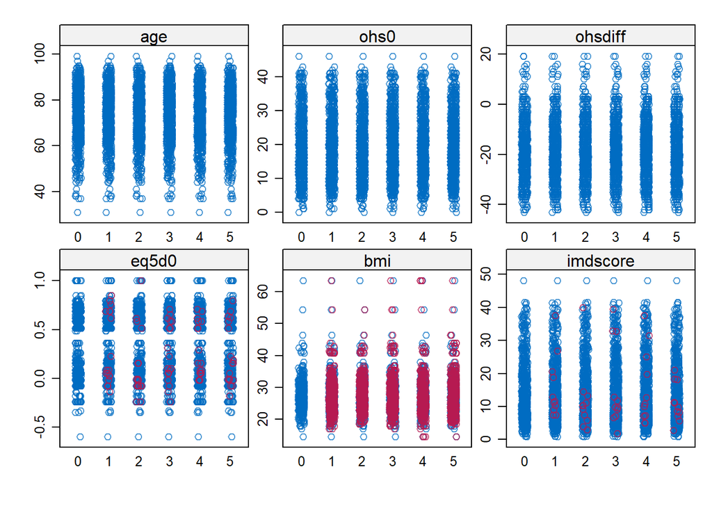

```r
#Observe which values has been imputed
stripplot(imp) #blue = observed data; red = imputed data
```

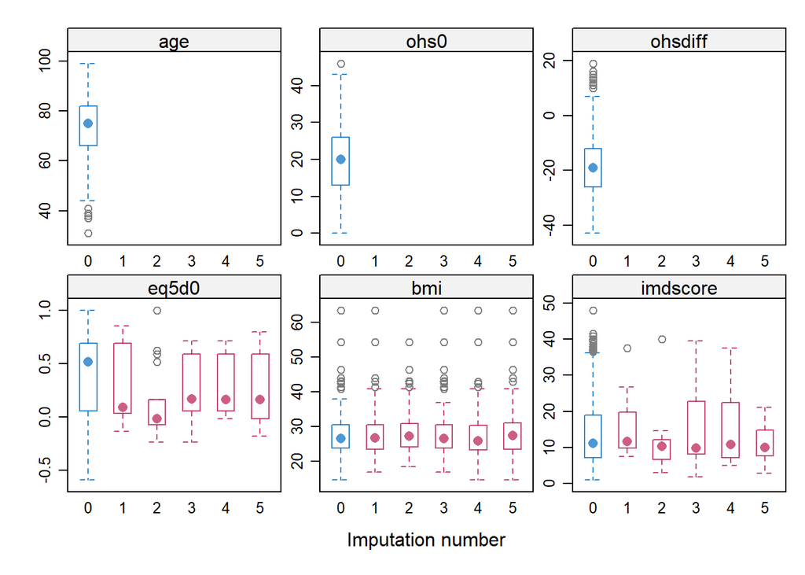

```r
bwplot(imp)    #blue = observed data; red = imputed data
```

#### 5.1 Evaluate differences between observed and imputed data:

##### 5.1.1. Observe their distribution before (observed) and after (imputed data):

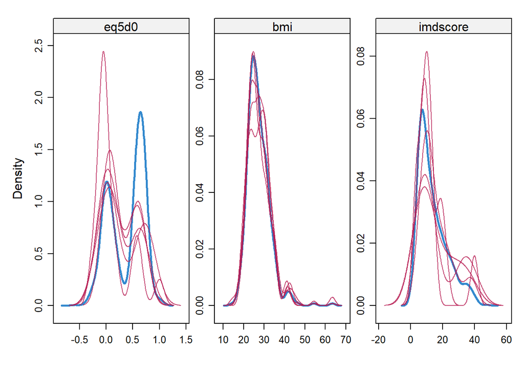

```r
densityplot(imp) #blue line = observed data; red lines = imputed data
```

##### 5.1.2. Compare the distributions of observed and imputed data conditional on the missingness probability.

Interpretation is more difficult if discrepancies are shown in the density plot. Such discrepancies may be caused by a bad imputation model, by a missing data mechanism that is not MCAR or by a combination of both.

If there are discrepancies, Bondarenko and Raghunathan (2016) proposed a more refined diagnostic tool that aims to compare the distributions of observed and imputed data conditional on the missingness probability. The idea is that under MAR the conditional distributions should be similar if the assumed model for creating multiple imputations has a good fit. An example is created as:

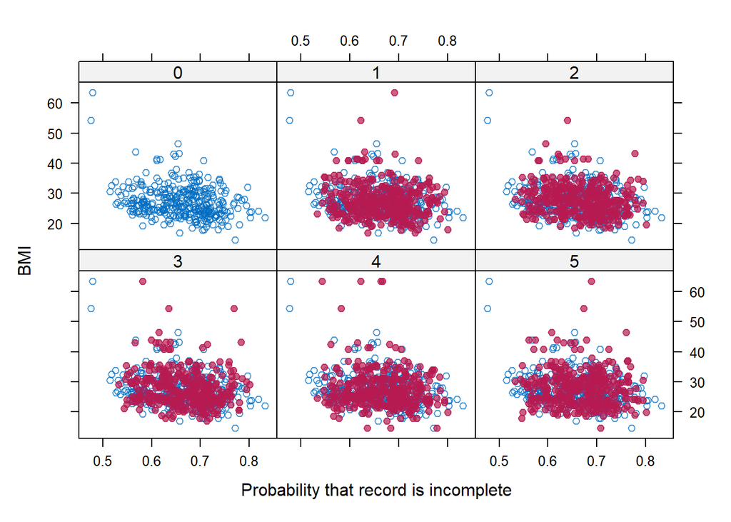

```r
#Model the probability of each record being incomplete as a function of all variables in each imputed data set.
fit <- with(imp, glm(ici(imp)~ohsdiff+age+sex+bmi+eq5d0+ethnic+imdscore+smoking+ohs0, family = binomial))

# The probabilities (propensities) are then averaged over the imputed datasets to obtain stability.
ps <- rep(rowMeans(sapply(fit$analyses, fitted.values)),
          imp$m + 1)

#Plot the each variable against the propensity score in each dataset:
#blue = observed data; red = imputed data
xyplot(imp, bmi ~ ps | as.factor(.imp),
       xlab = "Probability that record is incomplete",
       ylab = "BMI", pch = c(1, 19), col = mdc(1:2))
```

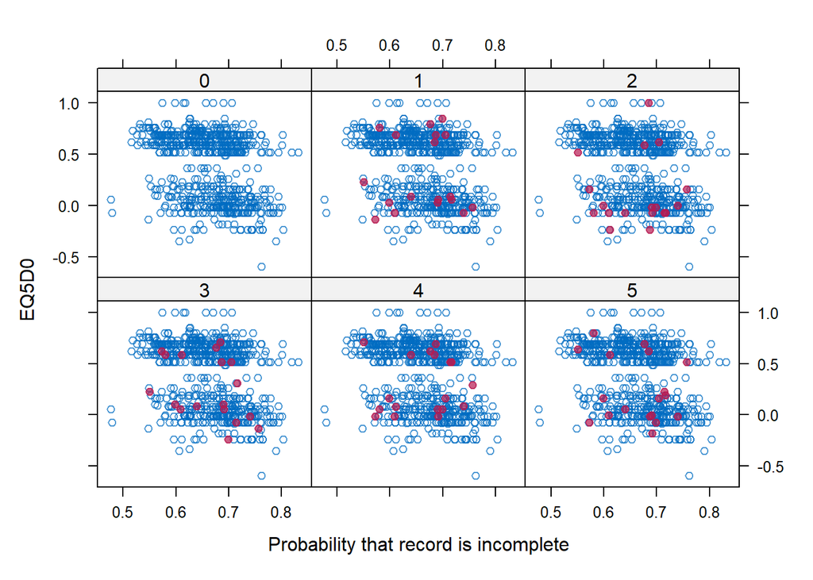

```r
xyplot(imp, eq5d0 ~ ps | as.factor(.imp),
       xlab = "Probability that record is incomplete",
       ylab = "EQ5D0", pch = c(1, 19), col = mdc(1:2))
```

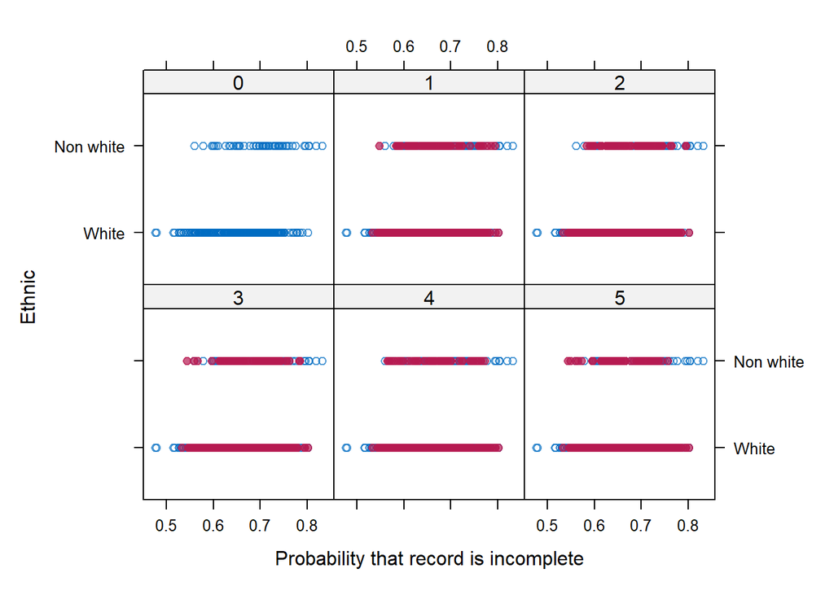

```r
xyplot(imp, ethnic ~ ps | as.factor(.imp),
       xlab = "Probability that record is incomplete",
       ylab = "Ethnic", pch = c(1, 19), col = mdc(1:2))
```

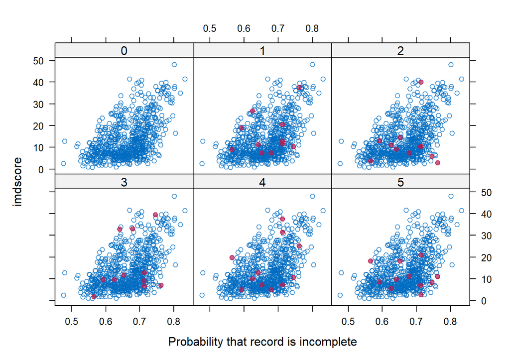

```r
xyplot(imp, imdscore ~ ps | as.factor(.imp),
       xlab = "Probability that record is incomplete",
       ylab = "imdscore", pch = c(1, 19), col = mdc(1:2))
```

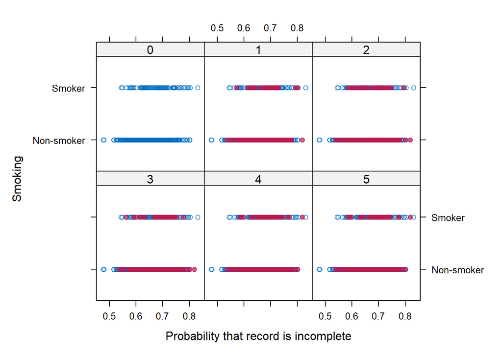

```r
xyplot(imp, smoking ~ ps | as.factor(.imp),
       xlab = "Probability that record is incomplete",
       ylab = "Smoking", pch = c(1, 19), col = mdc(1:2))
```

In this case, the distributions of the blue and red points are quite similar, as expected under MAR.

##### 5.1.3. Compare complete results vs imputed results

Observe the differences in the estimates and confidence intervals:

```r
#Complete cases results:variables names, OR, Low and High CI
fit0 =lm(ohsdiff~age+sex+bmi+eq5d0+ethnic+imdscore+smoking+ohs0, data=na.omit(data))
print("Using complete cases")
```

```
## [1] "Using complete cases"
```

```r
print( cbind(OR=summary(fit0)$coefficients[,1],confint(fit0)) )
```

```
##                           OR        2.5 %      97.5 %
## (Intercept)     -39.68808358 -50.22784423 -29.1483229
## age               0.08294092  -0.01261644   0.1784983
## sexFemale        -1.18934180  -3.45981471   1.0811311
## bmi               0.07068433  -0.13332738   0.2746961
## eq5d0            -2.29038866  -7.37888395   2.7981066
## ethnicNon white  -0.49522794  -3.63969230   2.6492364
## imdscore         -0.01737909  -0.13959133   0.1048331
## smokingSmoker     1.25328532  -1.65294807   4.1595187
## ohs0              0.73903797   0.56227462   0.9158013
```

```r
#Imputed results: variables names, OR, Low and High CI
fit = with(data=imp,expr = lm(ohsdiff~age+sex+bmi+eq5d0+ethnic+imdscore+smoking+ohs0))
print("Using imputed data")
```

```
## [1] "Using imputed data"
```

```r
summary(pool(fit), conf.int = TRUE)[c(1,2,7,8)]
```

```
##              term     estimate        2.5 %       97.5 %
## 1     (Intercept) -45.55267295 -54.68327348 -36.42207241
## 2             age   0.08143481   0.02245401   0.14041561
## 3       sexFemale   1.17602939  -0.20591809   2.55797687
## 4             bmi   0.18934270  -0.03587288   0.41455828
## 5           eq5d0  -0.86629440  -3.71512481   1.98253602
## 6 ethnicNon white  -0.13894990  -2.07458701   1.79668722
## 7        imdscore  -0.03233099  -0.10502211   0.04036014
## 8   smokingSmoker  -0.30304636  -2.23010920   1.62401648
## 9            ohs0   0.79330939   0.69178163   0.89483716
```

Interpretation: After imputation, age is significant in our model. Results regarding all other variables seems to be consistent before and after imputation.

### 6. What to do when a statistical analysis is not compatible with with() function

There might be cases where an analysis is such complex that you won’t be able to use the function with(). For this cases, the alternative is to store the imputed data sets into a list, run the desired methods using a loop, and later combine the results using Rubin’s rules.

6.1 Run imputation  
6.2 Extract the imputed data sets: imp.data is a data.frame that contains all the imputed data sets, which are distinguishable by the variable .imp  
6.3 See de number of individuals for each imputed data set  
6.4 Create a list for storing the results where the length is the number if imputed data sets  
6.5 Run a loop for each of the imputed data sets and store the results in the list created in the previous step.  
6.6 Transform the list into a mira object to perform the pooling  
6.7 Pool the results

```r
impmodel_var=c("age","sex","ohs0","ohsdiff","ethnic","eq5d0","bmi","imdscore","smoking")#3.2

imp = mice(data[impmodel_var], maxit=10, m = 5, seed=60109)   #6.1
imp.data = complete(imp , "long")   #6.2
table(imp.data$.imp)                #6.3
Fit.list = vector("list", length(unique(imp.data$.imp))) #6.4
Fit.list2= vector("list", length(unique(imp.data$.imp))) #6.4
for (i in unique(imp.data$.imp)) {  #6.5 Loop start
      fit = lm(ohsdiff~age+sex+ethnic+eq5d0+imdscore+bmi+smoking+ohs0, data = imp.data[imp.data$.imp == i,])
      Fit.list[[i]]= summary(fit)
                                  } #6.5 Loop end
Fit.list.mira = as.mira(Fit.list)   #6.6
```

```r
summary(pool(Fit.list.mira),conf.int = TRUE) #6.7
```

```
##              term     estimate  std.error   statistic         df      p.value
## 1     (Intercept) -45.55267295 4.37454925 -10.4131124  19.815470 1.758696e-09
## 2             age   0.08143481 0.02999356   2.7150770 366.990501 6.939110e-03
## 3       sexFemale   1.17602939 0.70285340   1.6732215 381.852610 9.510267e-02
## 4 ethnicNon white  -0.13894990 0.97725514  -0.1421838 115.658894 8.871822e-01
## 5           eq5d0  -0.86629440 1.44773881  -0.5983775 304.731295 5.500325e-01
## 6        imdscore  -0.03233099 0.03696526  -0.8746316 365.742018 3.823484e-01
## 7             bmi   0.18934270 0.10052389   1.8835593   9.611156 9.019527e-02
## 8   smokingSmoker  -0.30304636 0.96771460  -0.3131567  76.758155 7.550109e-01
## 9            ohs0   0.79330939 0.05167490  15.3519282 497.855121 7.919158e-44
##          2.5 %       97.5 %
## 1 -54.68327348 -36.42207241
## 2   0.02245401   0.14041561
## 3  -0.20591809   2.55797687
## 4  -2.07458701   1.79668722
## 5  -3.71512481   1.98253602
## 6  -0.10502211   0.04036014
## 7  -0.03587288   0.41455828
## 8  -2.23010920   1.62401648
## 9   0.69178163   0.89483716
```